# Zomato EDA

```python
# importing major libraries

import pandas as pd
import numpy as np
import seaborn as sns
import matplotlib.pyplot as plt
import plotly.express as px
from wordcloud import WordCloud
import warnings
warnings.filterwarnings('ignore')
```

```python
# loading dataset

df = pd.read_csv('Zomato_CleanData.csv')
```

```python
# Viewing dataset

df
```

|  | Unnamed: 0 | name | establishment | url | address | city | city_id | locality | latitude | longitude | ... | timings | average_cost_for_two | price_range | highlights | aggregate_rating | rating_text | votes | photo_count | delivery | takeaway |
| --- | --- | --- | --- | --- | --- | --- | --- | --- | --- | --- | --- | --- | --- | --- | --- | --- | --- | --- | --- | --- | --- |
| 0 | 0 | Bikanervala | ['Quick Bites'] | https://www.zomato.com/agra/bikanervala-khanda... | Kalyani Point, Near Tulsi Cinema, Bypass Road,... | Agra | 34 | Khandari | 27.211450 | 78.002381 | ... | 8:30am – 10:30pm (Mon-Sun) | 700 | 2 | ['Lunch', 'Takeaway Available', 'Credit Card',... | 4.4 | Very Good | 814 | 154 | -1 | -1 |
| 1 | 1 | Mama Chicken Mama Franky House | ['Quick Bites'] | https://www.zomato.com/agra/mama-chicken-mama-... | Main Market, Sadar Bazaar, Agra Cantt, Agra | Agra | 34 | Agra Cantt | 27.160569 | 78.011583 | ... | 12:30PM to 12Midnight (Mon, Wed, Thu, Fri, Sat... | 600 | 2 | ['Delivery', 'No Alcohol Available', 'Dinner',... | 4.4 | Very Good | 1203 | 161 | -1 | -1 |
| 2 | 2 | Bhagat Halwai | ['Quick Bites'] | https://www.zomato.com/agra/bhagat-halwai-2-sh... | 62/1, Near Easy Day, West Shivaji Nagar, Goalp... | Agra | 34 | Shahganj | 27.182938 | 77.979684 | ... | 9:30 AM to 11 PM | 300 | 1 | ['No Alcohol Available', 'Dinner', 'Takeaway A... | 4.2 | Very Good | 801 | 107 | 1 | -1 |
| 3 | 3 | Bhagat Halwai | ['Quick Bites'] | https://www.zomato.com/agra/bhagat-halwai-civi... | Near Anjana Cinema, Nehru Nagar, Civil Lines, ... | Agra | 34 | Civil Lines | 27.205668 | 78.004799 | ... | 8am – 11pm (Mon-Sun) | 300 | 1 | ['Takeaway Available', 'Credit Card', 'Lunch',... | 4.3 | Very Good | 693 | 157 | 1 | -1 |
| 4 | 4 | The Salt Cafe Kitchen & Bar | ['Casual Dining'] | https://www.zomato.com/agra/the-salt-cafe-kitc... | 1C,3rd Floor, Fatehabad Road, Tajganj, Agra | Agra | 34 | Tajganj | 27.157709 | 78.052421 | ... | 11:30 AM to 11:30 PM | 1000 | 3 | ['Lunch', 'Serves Alcohol', 'Cash', 'Credit Ca... | 4.9 | Excellent | 470 | 291 | 1 | -1 |
| ... | ... | ... | ... | ... | ... | ... | ... | ... | ... | ... | ... | ... | ... | ... | ... | ... | ... | ... | ... | ... | ... |
| 211939 | 211939 | Kali Mirch Cafe And Restaurant | ['Casual Dining'] | https://www.zomato.com/vadodara/kali-mirch-caf... | Manu Smriti Complex, Near Navrachna School, GI... | Vadodara | 32 | Fatehgunj | 22.336931 | 73.192356 | ... | 11am – 3pm, 7pm – 11:30pm (Mon-Sun) | 600 | 2 | ['Dinner', 'Cash', 'Lunch', 'Delivery', 'Indoo... | 4.1 | Very Good | 243 | 40 | -1 | -1 |
| 211940 | 211940 | Raju Omlet | ['Quick Bites'] | https://www.zomato.com/vadodara/raju-omlet-kar... | Mahalaxmi Apartment, Opposite B O B, Karoli Ba... | Vadodara | 32 | Karelibaug | 22.322455 | 73.197203 | ... | 4pm – 11pm (Mon, Tue, Wed, Fri, Sat, Sun), 4pm... | 300 | 1 | ['Dinner', 'Cash', 'Takeaway Available', 'Debi... | 4.1 | Very Good | 187 | 40 | 1 | -1 |
| 211941 | 211941 | The Grand Thakar | ['Casual Dining'] | https://www.zomato.com/vadodara/the-grand-thak... | 3rd Floor, Shreem Shalini Mall, Opposite Conqu... | Vadodara | 32 | Alkapuri | 22.310563 | 73.171163 | ... | 11:30 AM to 3:30 PM, 7:30 PM to 11 PM | 700 | 2 | ['Dinner', 'Cash', 'Debit Card', 'Lunch', 'Tak... | 4.0 | Very Good | 111 | 38 | -1 | -1 |
| 211942 | 211942 | Subway | ['Quick Bites'] | https://www.zomato.com/vadodara/subway-1-akota... | G-2, Vedant Platina, Near Cosmos, Akota, Vadodara | Vadodara | 32 | Akota | 22.270027 | 73.143068 | ... | 8 AM to 1 AM | 500 | 2 | ['Dinner', 'Delivery', 'Credit Card', 'Lunch',... | 3.7 | Good | 128 | 34 | 1 | -1 |
| 211943 | 211943 | Freshco's - The Health Cafe | ['Café'] | https://www.zomato.com/vadodara/freshcos-the-h... | Shop 7, Ground Floor, Opposite Natubhai Circle... | Vadodara | 32 | Vadiwadi | 22.309935 | 73.158768 | ... | 7am – 11pm (Mon-Sun) | 600 | 2 | ['Dinner', 'Cash', 'Takeaway Available', 'Debi... | 4.0 | Very Good | 93 | 53 | 1 | -1 |

211944 rows × 23 columns

```python
# Dropping Unneccessary columns

df = df.drop(columns=['Unnamed: 0'])
```

```python
# Viewing dataset

df
```

|  | name | establishment | url | address | city | city_id | locality | latitude | longitude | zipcode | ... | timings | average_cost_for_two | price_range | highlights | aggregate_rating | rating_text | votes | photo_count | delivery | takeaway |
| --- | --- | --- | --- | --- | --- | --- | --- | --- | --- | --- | --- | --- | --- | --- | --- | --- | --- | --- | --- | --- | --- |
| 0 | Bikanervala | ['Quick Bites'] | https://www.zomato.com/agra/bikanervala-khanda... | Kalyani Point, Near Tulsi Cinema, Bypass Road,... | Agra | 34 | Khandari | 27.211450 | 78.002381 | 282002 | ... | 8:30am – 10:30pm (Mon-Sun) | 700 | 2 | ['Lunch', 'Takeaway Available', 'Credit Card',... | 4.4 | Very Good | 814 | 154 | -1 | -1 |
| 1 | Mama Chicken Mama Franky House | ['Quick Bites'] | https://www.zomato.com/agra/mama-chicken-mama-... | Main Market, Sadar Bazaar, Agra Cantt, Agra | Agra | 34 | Agra Cantt | 27.160569 | 78.011583 | 282001 | ... | 12:30PM to 12Midnight (Mon, Wed, Thu, Fri, Sat... | 600 | 2 | ['Delivery', 'No Alcohol Available', 'Dinner',... | 4.4 | Very Good | 1203 | 161 | -1 | -1 |
| 2 | Bhagat Halwai | ['Quick Bites'] | https://www.zomato.com/agra/bhagat-halwai-2-sh... | 62/1, Near Easy Day, West Shivaji Nagar, Goalp... | Agra | 34 | Shahganj | 27.182938 | 77.979684 | 282010 | ... | 9:30 AM to 11 PM | 300 | 1 | ['No Alcohol Available', 'Dinner', 'Takeaway A... | 4.2 | Very Good | 801 | 107 | 1 | -1 |
| 3 | Bhagat Halwai | ['Quick Bites'] | https://www.zomato.com/agra/bhagat-halwai-civi... | Near Anjana Cinema, Nehru Nagar, Civil Lines, ... | Agra | 34 | Civil Lines | 27.205668 | 78.004799 | 282002 | ... | 8am – 11pm (Mon-Sun) | 300 | 1 | ['Takeaway Available', 'Credit Card', 'Lunch',... | 4.3 | Very Good | 693 | 157 | 1 | -1 |
| 4 | The Salt Cafe Kitchen & Bar | ['Casual Dining'] | https://www.zomato.com/agra/the-salt-cafe-kitc... | 1C,3rd Floor, Fatehabad Road, Tajganj, Agra | Agra | 34 | Tajganj | 27.157709 | 78.052421 | 282001 | ... | 11:30 AM to 11:30 PM | 1000 | 3 | ['Lunch', 'Serves Alcohol', 'Cash', 'Credit Ca... | 4.9 | Excellent | 470 | 291 | 1 | -1 |
| ... | ... | ... | ... | ... | ... | ... | ... | ... | ... | ... | ... | ... | ... | ... | ... | ... | ... | ... | ... | ... | ... |
| 211939 | Kali Mirch Cafe And Restaurant | ['Casual Dining'] | https://www.zomato.com/vadodara/kali-mirch-caf... | Manu Smriti Complex, Near Navrachna School, GI... | Vadodara | 32 | Fatehgunj | 22.336931 | 73.192356 | 390024 | ... | 11am – 3pm, 7pm – 11:30pm (Mon-Sun) | 600 | 2 | ['Dinner', 'Cash', 'Lunch', 'Delivery', 'Indoo... | 4.1 | Very Good | 243 | 40 | -1 | -1 |
| 211940 | Raju Omlet | ['Quick Bites'] | https://www.zomato.com/vadodara/raju-omlet-kar... | Mahalaxmi Apartment, Opposite B O B, Karoli Ba... | Vadodara | 32 | Karelibaug | 22.322455 | 73.197203 | 390018 | ... | 4pm – 11pm (Mon, Tue, Wed, Fri, Sat, Sun), 4pm... | 300 | 1 | ['Dinner', 'Cash', 'Takeaway Available', 'Debi... | 4.1 | Very Good | 187 | 40 | 1 | -1 |
| 211941 | The Grand Thakar | ['Casual Dining'] | https://www.zomato.com/vadodara/the-grand-thak... | 3rd Floor, Shreem Shalini Mall, Opposite Conqu... | Vadodara | 32 | Alkapuri | 22.310563 | 73.171163 | 390007 | ... | 11:30 AM to 3:30 PM, 7:30 PM to 11 PM | 700 | 2 | ['Dinner', 'Cash', 'Debit Card', 'Lunch', 'Tak... | 4.0 | Very Good | 111 | 38 | -1 | -1 |
| 211942 | Subway | ['Quick Bites'] | https://www.zomato.com/vadodara/subway-1-akota... | G-2, Vedant Platina, Near Cosmos, Akota, Vadodara | Vadodara | 32 | Akota | 22.270027 | 73.143068 | 390020 | ... | 8 AM to 1 AM | 500 | 2 | ['Dinner', 'Delivery', 'Credit Card', 'Lunch',... | 3.7 | Good | 128 | 34 | 1 | -1 |
| 211943 | Freshco's - The Health Cafe | ['Café'] | https://www.zomato.com/vadodara/freshcos-the-h... | Shop 7, Ground Floor, Opposite Natubhai Circle... | Vadodara | 32 | Vadiwadi | 22.309935 | 73.158768 | 390007 | ... | 7am – 11pm (Mon-Sun) | 600 | 2 | ['Dinner', 'Cash', 'Takeaway Available', 'Debi... | 4.0 | Very Good | 93 | 53 | 1 | -1 |

211944 rows × 22 columns

```python
# Viewing all columns
pd.set_option('display.max_columns',None)
```

```python
# Viewing dataset

df
```

|  | name | establishment | url | address | city | city_id | locality | latitude | longitude | zipcode | locality_verbose | cuisines | timings | average_cost_for_two | price_range | highlights | aggregate_rating | rating_text | votes | photo_count | delivery | takeaway |
| --- | --- | --- | --- | --- | --- | --- | --- | --- | --- | --- | --- | --- | --- | --- | --- | --- | --- | --- | --- | --- | --- | --- |
| 0 | Bikanervala | ['Quick Bites'] | https://www.zomato.com/agra/bikanervala-khanda... | Kalyani Point, Near Tulsi Cinema, Bypass Road,... | Agra | 34 | Khandari | 27.211450 | 78.002381 | 282002 | Khandari, Agra | North Indian, South Indian, Mithai, Street Foo... | 8:30am – 10:30pm (Mon-Sun) | 700 | 2 | ['Lunch', 'Takeaway Available', 'Credit Card',... | 4.4 | Very Good | 814 | 154 | -1 | -1 |
| 1 | Mama Chicken Mama Franky House | ['Quick Bites'] | https://www.zomato.com/agra/mama-chicken-mama-... | Main Market, Sadar Bazaar, Agra Cantt, Agra | Agra | 34 | Agra Cantt | 27.160569 | 78.011583 | 282001 | Agra Cantt, Agra | North Indian, Mughlai, Rolls, Chinese, Fast Fo... | 12:30PM to 12Midnight (Mon, Wed, Thu, Fri, Sat... | 600 | 2 | ['Delivery', 'No Alcohol Available', 'Dinner',... | 4.4 | Very Good | 1203 | 161 | -1 | -1 |
| 2 | Bhagat Halwai | ['Quick Bites'] | https://www.zomato.com/agra/bhagat-halwai-2-sh... | 62/1, Near Easy Day, West Shivaji Nagar, Goalp... | Agra | 34 | Shahganj | 27.182938 | 77.979684 | 282010 | Shahganj, Agra | Fast Food, Mithai | 9:30 AM to 11 PM | 300 | 1 | ['No Alcohol Available', 'Dinner', 'Takeaway A... | 4.2 | Very Good | 801 | 107 | 1 | -1 |
| 3 | Bhagat Halwai | ['Quick Bites'] | https://www.zomato.com/agra/bhagat-halwai-civi... | Near Anjana Cinema, Nehru Nagar, Civil Lines, ... | Agra | 34 | Civil Lines | 27.205668 | 78.004799 | 282002 | Civil Lines, Agra | Desserts, Bakery, Fast Food, South Indian | 8am – 11pm (Mon-Sun) | 300 | 1 | ['Takeaway Available', 'Credit Card', 'Lunch',... | 4.3 | Very Good | 693 | 157 | 1 | -1 |
| 4 | The Salt Cafe Kitchen & Bar | ['Casual Dining'] | https://www.zomato.com/agra/the-salt-cafe-kitc... | 1C,3rd Floor, Fatehabad Road, Tajganj, Agra | Agra | 34 | Tajganj | 27.157709 | 78.052421 | 282001 | Tajganj, Agra | North Indian, Continental, Italian | 11:30 AM to 11:30 PM | 1000 | 3 | ['Lunch', 'Serves Alcohol', 'Cash', 'Credit Ca... | 4.9 | Excellent | 470 | 291 | 1 | -1 |
| ... | ... | ... | ... | ... | ... | ... | ... | ... | ... | ... | ... | ... | ... | ... | ... | ... | ... | ... | ... | ... | ... | ... |
| 211939 | Kali Mirch Cafe And Restaurant | ['Casual Dining'] | https://www.zomato.com/vadodara/kali-mirch-caf... | Manu Smriti Complex, Near Navrachna School, GI... | Vadodara | 32 | Fatehgunj | 22.336931 | 73.192356 | 390024 | Fatehgunj, Vadodara | North Indian | 11am – 3pm, 7pm – 11:30pm (Mon-Sun) | 600 | 2 | ['Dinner', 'Cash', 'Lunch', 'Delivery', 'Indoo... | 4.1 | Very Good | 243 | 40 | -1 | -1 |
| 211940 | Raju Omlet | ['Quick Bites'] | https://www.zomato.com/vadodara/raju-omlet-kar... | Mahalaxmi Apartment, Opposite B O B, Karoli Ba... | Vadodara | 32 | Karelibaug | 22.322455 | 73.197203 | 390018 | Karelibaug, Vadodara | Fast Food | 4pm – 11pm (Mon, Tue, Wed, Fri, Sat, Sun), 4pm... | 300 | 1 | ['Dinner', 'Cash', 'Takeaway Available', 'Debi... | 4.1 | Very Good | 187 | 40 | 1 | -1 |
| 211941 | The Grand Thakar | ['Casual Dining'] | https://www.zomato.com/vadodara/the-grand-thak... | 3rd Floor, Shreem Shalini Mall, Opposite Conqu... | Vadodara | 32 | Alkapuri | 22.310563 | 73.171163 | 390007 | Alkapuri, Vadodara | Gujarati, North Indian, Chinese | 11:30 AM to 3:30 PM, 7:30 PM to 11 PM | 700 | 2 | ['Dinner', 'Cash', 'Debit Card', 'Lunch', 'Tak... | 4.0 | Very Good | 111 | 38 | -1 | -1 |
| 211942 | Subway | ['Quick Bites'] | https://www.zomato.com/vadodara/subway-1-akota... | G-2, Vedant Platina, Near Cosmos, Akota, Vadodara | Vadodara | 32 | Akota | 22.270027 | 73.143068 | 390020 | Akota, Vadodara | Fast Food, Sandwich, Salad | 8 AM to 1 AM | 500 | 2 | ['Dinner', 'Delivery', 'Credit Card', 'Lunch',... | 3.7 | Good | 128 | 34 | 1 | -1 |
| 211943 | Freshco's - The Health Cafe | ['Café'] | https://www.zomato.com/vadodara/freshcos-the-h... | Shop 7, Ground Floor, Opposite Natubhai Circle... | Vadodara | 32 | Vadiwadi | 22.309935 | 73.158768 | 390007 | Vadiwadi, Vadodara | Cafe, Healthy Food, Coffee | 7am – 11pm (Mon-Sun) | 600 | 2 | ['Dinner', 'Cash', 'Takeaway Available', 'Debi... | 4.0 | Very Good | 93 | 53 | 1 | -1 |

211944 rows × 22 columns

### Outlier Detection

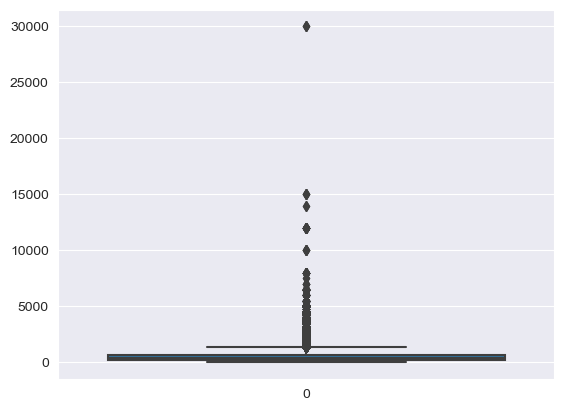

```python
# Outliers detection in average price for 2

sns.set_style("darkgrid")
sns.boxplot(df.average_cost_for_two)
```

- Prominent outliers are observed to be concentrated beyond the 1600 range.

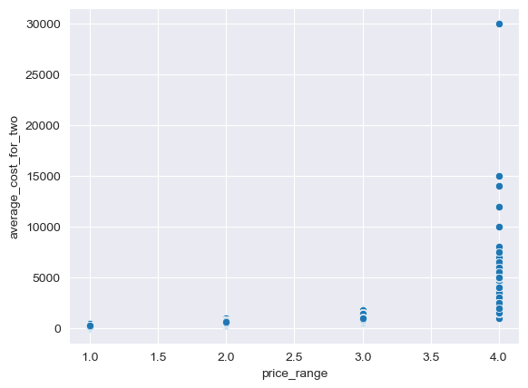

```python
sns.scatterplot(y=df.average_cost_for_two, x=df.price_range)
```

- Based on our research, prices up to 10,000 are deemed acceptable.
- A notable outlier is evident, exhibiting an average cost for two at 30,000.

```python
# Viewing rows with price 30,000

df[df.average_cost_for_two==30000]
```

|  | name | establishment | url | address | city | city_id | locality | latitude | longitude | zipcode | locality_verbose | cuisines | timings | average_cost_for_two | price_range | highlights | aggregate_rating | rating_text | votes | photo_count | delivery | takeaway |
| --- | --- | --- | --- | --- | --- | --- | --- | --- | --- | --- | --- | --- | --- | --- | --- | --- | --- | --- | --- | --- | --- | --- |
| 136240 | Ocean - The Private Dining Room - Sahara Star | ['Fine Dining'] | https://www.zomato.com/mumbai/ocean-the-privat... | Hotel Sahara Star, Opposite Domestic Airport, ... | Mumbai | 3 | Sahara Star, Vile Parle East | 19.094752 | 72.854226 | 400099 | Sahara Star, Vile Parle East, Mumbai | Asian, Seafood, North Indian, Mediterranean | 12 Noon to 3 PM, 7 PM to 12 Midnight (Mon-Sun) | 30000 | 4 | ['Dinner', 'Serves Alcohol', 'Debit Card', 'Ca... | 3.6 | Good | 91 | 31 | -1 | -1 |
| 136740 | Ocean - The Private Dining Room - Sahara Star | ['Fine Dining'] | https://www.zomato.com/mumbai/ocean-the-privat... | Hotel Sahara Star, Opposite Domestic Airport, ... | Mumbai | 3 | Sahara Star, Vile Parle East | 19.094752 | 72.854226 | 400099 | Sahara Star, Vile Parle East, Mumbai | Asian, Seafood, North Indian, Mediterranean | 12 Noon to 3 PM, 7 PM to 12 Midnight (Mon-Sun) | 30000 | 4 | ['Dinner', 'Serves Alcohol', 'Debit Card', 'Ca... | 3.6 | Good | 91 | 31 | -1 | -1 |
| 137240 | Ocean - The Private Dining Room - Sahara Star | ['Fine Dining'] | https://www.zomato.com/mumbai/ocean-the-privat... | Hotel Sahara Star, Opposite Domestic Airport, ... | Mumbai | 3 | Sahara Star, Vile Parle East | 19.094752 | 72.854226 | 400099 | Sahara Star, Vile Parle East, Mumbai | Asian, Seafood, North Indian, Mediterranean | 12 Noon to 3 PM, 7 PM to 12 Midnight (Mon-Sun) | 30000 | 4 | ['Dinner', 'Serves Alcohol', 'Debit Card', 'Ca... | 3.6 | Good | 91 | 31 | -1 | -1 |

- Based on our research, it appears to be a data entry error. The correct value should likely be 3,000, as opposed to the mistakenly recorded 30,000.

```python
# Correcting value of average_cost_for_two for Ocean - The Private Dining Room

df['average_cost_for_two'] = np.where(df['average_cost_for_two'] == 30000, 3000, df['average_cost_for_two'])
```

```python
df[df.average_cost_for_two==30000]
```

|  | name | establishment | url | address | city | city_id | locality | latitude | longitude | zipcode | locality_verbose | cuisines | timings | average_cost_for_two | price_range | highlights | aggregate_rating | rating_text | votes | photo_count | delivery | takeaway |
| --- | --- | --- | --- | --- | --- | --- | --- | --- | --- | --- | --- | --- | --- | --- | --- | --- | --- | --- | --- | --- | --- | --- |

- The outlier has been effectively substituted with the accurate value.

```python
# Viewing places where average cost for two is above 10000

df[df.average_cost_for_two>=10000]
```

|  | name | establishment | url | address | city | city_id | locality | latitude | longitude | zipcode | locality_verbose | cuisines | timings | average_cost_for_two | price_range | highlights | aggregate_rating | rating_text | votes | photo_count | delivery | takeaway |
| --- | --- | --- | --- | --- | --- | --- | --- | --- | --- | --- | --- | --- | --- | --- | --- | --- | --- | --- | --- | --- | --- | --- |
| 19730 | Fly Dining | ['Fine Dining'] | https://www.zomato.com/bangalore/fly-dining-na... | House Of Life, Near Manyata Tech Park, Nagawar... | Bangalore | 4 | Nagawara | 13.047513 | 77.610328 | 560024 | Nagawara, Bangalore | Continental, North Indian | 2 PM to 11 PM | 14000 | 4 | ['Serves Alcohol', 'Credit Card', 'Dinner', 'C... | 3.8 | Good | 136 | 27 | -1 | -1 |
| 20312 | Fly Dining | ['Fine Dining'] | https://www.zomato.com/bangalore/fly-dining-na... | House Of Life, Near Manyata Tech Park, Nagawar... | Bangalore | 4 | Nagawara | 13.047513 | 77.610328 | 560024 | Nagawara, Bangalore | Continental, North Indian | 2 PM to 11 PM | 14000 | 4 | ['Serves Alcohol', 'Credit Card', 'Dinner', 'C... | 3.8 | Good | 136 | 27 | -1 | -1 |
| 77501 | Gol Bungalow - Taj Falaknuma Palace | ['Fine Dining'] | https://www.zomato.com/hyderabad/gol-bungalow-... | Taj Falaknuma Palace, Falaknuma, Hyderabad | Hyderabad | 6 | Taj Falaknuma, Falaknuma | 17.334338 | 78.467603 | 0 | Taj Falaknuma, Falaknuma, Hyderabad | North Indian, Italian | 7:30 PM to 11:30 PM | 15000 | 4 | ['Cash', 'Dinner', 'Credit Card', 'No Alcohol ... | 3.9 | Good | 38 | 20 | -1 | -1 |
| 100988 | Risala- Umaid Bhawan Palace | ['Fine Dining'] | https://www.zomato.com/jodhpur/risala-umaid-bh... | Umaid Bhawan Palace, Circuit House Road, Cantt... | Jodhpur | 11301 | Umaid Bhawan Palace, Cantt Area | 26.281107 | 73.046799 | 0 | Umaid Bhawan Palace, Cantt Area, Jodhpur | North Indian | 12:30 PM to 3 PM, 7 PM to 10:30 PM | 12000 | 4 | ['Cash', 'Debit Card', 'Dinner', 'Serves Alcoh... | 4.1 | Very Good | 77 | 57 | -1 | -1 |
| 101039 | Risala- Umaid Bhawan Palace | ['Fine Dining'] | https://www.zomato.com/jodhpur/risala-umaid-bh... | Umaid Bhawan Palace, Circuit House Road, Cantt... | Jodhpur | 11301 | Umaid Bhawan Palace, Cantt Area | 26.281107 | 73.046799 | 0 | Umaid Bhawan Palace, Cantt Area, Jodhpur | North Indian | 12:30 PM to 3 PM, 7 PM to 10:30 PM | 12000 | 4 | ['Cash', 'Debit Card', 'Dinner', 'Serves Alcoh... | 4.1 | Very Good | 77 | 57 | -1 | -1 |
| 101040 | Pillars - Umaid Bhawan Palace | ['Fine Dining'] | https://www.zomato.com/jodhpur/pillars-umaid-b... | Umed Bhawan Palace, Cantt Area, Jodhpur | Jodhpur | 11301 | Umaid Bhawan Palace, Cantt Area | 26.281143 | 73.047179 | 0 | Umaid Bhawan Palace, Cantt Area, Jodhpur | Continental, Italian, Asian | 7 AM to 11 AM, 7 PM to 11 PM | 12000 | 4 | ['Credit Card', 'Debit Card', 'Dinner', 'Cash'... | 3.6 | Good | 27 | 10 | -1 | -1 |
| 101041 | Trophy Bar- Umaid Bhawan Palace | ['Bar'] | https://www.zomato.com/jodhpur/trophy-bar-umai... | Umed Bhawan Palace, Cantt Area, Jodhpur | Jodhpur | 11301 | Umaid Bhawan Palace, Cantt Area | 26.281143 | 73.047179 | 0 | Umaid Bhawan Palace, Cantt Area, Jodhpur | Finger Food | 12 Noon to 10:30 PM | 12000 | 4 | ['Dinner', 'Cash', 'Debit Card', 'Lunch', 'Cre... | 3.2 | Average | 9 | 3 | -1 | -1 |
| 101293 | Risala- Umaid Bhawan Palace | ['Fine Dining'] | https://www.zomato.com/jodhpur/risala-umaid-bh... | Umaid Bhawan Palace, Circuit House Road, Cantt... | Jodhpur | 11301 | Umaid Bhawan Palace, Cantt Area | 26.281107 | 73.046799 | 0 | Umaid Bhawan Palace, Cantt Area, Jodhpur | North Indian | 12:30 PM to 3 PM, 7 PM to 10:30 PM | 12000 | 4 | ['Cash', 'Debit Card', 'Dinner', 'Serves Alcoh... | 4.1 | Very Good | 77 | 57 | -1 | -1 |
| 101475 | Risala- Umaid Bhawan Palace | ['Fine Dining'] | https://www.zomato.com/jodhpur/risala-umaid-bh... | Umaid Bhawan Palace, Circuit House Road, Cantt... | Jodhpur | 11301 | Umaid Bhawan Palace, Cantt Area | 26.281107 | 73.046799 | 0 | Umaid Bhawan Palace, Cantt Area, Jodhpur | North Indian | 12:30 PM to 3 PM, 7 PM to 10:30 PM | 12000 | 4 | ['Cash', 'Debit Card', 'Dinner', 'Serves Alcoh... | 4.1 | Very Good | 77 | 57 | -1 | -1 |
| 101645 | Trophy Bar- Umaid Bhawan Palace | ['Bar'] | https://www.zomato.com/jodhpur/trophy-bar-umai... | Umed Bhawan Palace, Cantt Area, Jodhpur | Jodhpur | 11301 | Umaid Bhawan Palace, Cantt Area | 26.281143 | 73.047179 | 0 | Umaid Bhawan Palace, Cantt Area, Jodhpur | Finger Food | 12 Noon to 10:30 PM | 12000 | 4 | ['Dinner', 'Cash', 'Debit Card', 'Lunch', 'Cre... | 3.2 | Average | 9 | 3 | -1 | -1 |
| 102073 | Risala- Umaid Bhawan Palace | ['Fine Dining'] | https://www.zomato.com/jodhpur/risala-umaid-bh... | Umaid Bhawan Palace, Circuit House Road, Cantt... | Jodhpur | 11301 | Umaid Bhawan Palace, Cantt Area | 26.281107 | 73.046799 | 0 | Umaid Bhawan Palace, Cantt Area, Jodhpur | North Indian | 12:30 PM to 3 PM, 7 PM to 10:30 PM | 12000 | 4 | ['Cash', 'Debit Card', 'Dinner', 'Serves Alcoh... | 4.1 | Very Good | 77 | 57 | -1 | -1 |
| 102081 | Pillars - Umaid Bhawan Palace | ['Fine Dining'] | https://www.zomato.com/jodhpur/pillars-umaid-b... | Umed Bhawan Palace, Cantt Area, Jodhpur | Jodhpur | 11301 | Umaid Bhawan Palace, Cantt Area | 26.281143 | 73.047179 | 0 | Umaid Bhawan Palace, Cantt Area, Jodhpur | Continental, Italian, Asian | 7 AM to 11 AM, 7 PM to 11 PM | 12000 | 4 | ['Credit Card', 'Debit Card', 'Dinner', 'Cash'... | 3.6 | Good | 27 | 10 | -1 | -1 |
| 102251 | Risala- Umaid Bhawan Palace | ['Fine Dining'] | https://www.zomato.com/jodhpur/risala-umaid-bh... | Umaid Bhawan Palace, Circuit House Road, Cantt... | Jodhpur | 11301 | Umaid Bhawan Palace, Cantt Area | 26.281107 | 73.046799 | 0 | Umaid Bhawan Palace, Cantt Area, Jodhpur | North Indian | 12:30 PM to 3 PM, 7 PM to 10:30 PM | 12000 | 4 | ['Cash', 'Debit Card', 'Dinner', 'Serves Alcoh... | 4.1 | Very Good | 77 | 57 | -1 | -1 |
| 102558 | Pillars - Umaid Bhawan Palace | ['Fine Dining'] | https://www.zomato.com/jodhpur/pillars-umaid-b... | Umed Bhawan Palace, Cantt Area, Jodhpur | Jodhpur | 11301 | Umaid Bhawan Palace, Cantt Area | 26.281143 | 73.047179 | 0 | Umaid Bhawan Palace, Cantt Area, Jodhpur | Continental, Italian, Asian | 7 AM to 11 AM, 7 PM to 11 PM | 12000 | 4 | ['Credit Card', 'Debit Card', 'Dinner', 'Cash'... | 3.6 | Good | 27 | 10 | -1 | -1 |
| 102643 | Risala- Umaid Bhawan Palace | ['Fine Dining'] | https://www.zomato.com/jodhpur/risala-umaid-bh... | Umaid Bhawan Palace, Circuit House Road, Cantt... | Jodhpur | 11301 | Umaid Bhawan Palace, Cantt Area | 26.281107 | 73.046799 | 0 | Umaid Bhawan Palace, Cantt Area, Jodhpur | North Indian | 12:30 PM to 3 PM, 7 PM to 10:30 PM | 12000 | 4 | ['Cash', 'Debit Card', 'Dinner', 'Serves Alcoh... | 4.1 | Very Good | 77 | 57 | -1 | -1 |
| 102749 | Risala- Umaid Bhawan Palace | ['Fine Dining'] | https://www.zomato.com/jodhpur/risala-umaid-bh... | Umaid Bhawan Palace, Circuit House Road, Cantt... | Jodhpur | 11301 | Umaid Bhawan Palace, Cantt Area | 26.281107 | 73.046799 | 0 | Umaid Bhawan Palace, Cantt Area, Jodhpur | North Indian | 12:30 PM to 3 PM, 7 PM to 10:30 PM | 12000 | 4 | ['Cash', 'Debit Card', 'Dinner', 'Serves Alcoh... | 4.1 | Very Good | 77 | 57 | -1 | -1 |
| 102856 | Risala- Umaid Bhawan Palace | ['Fine Dining'] | https://www.zomato.com/jodhpur/risala-umaid-bh... | Umaid Bhawan Palace, Circuit House Road, Cantt... | Jodhpur | 11301 | Umaid Bhawan Palace, Cantt Area | 26.281107 | 73.046799 | 0 | Umaid Bhawan Palace, Cantt Area, Jodhpur | North Indian | 12:30 PM to 3 PM, 7 PM to 10:30 PM | 12000 | 4 | ['Cash', 'Debit Card', 'Dinner', 'Serves Alcoh... | 4.1 | Very Good | 77 | 57 | -1 | -1 |
| 102956 | Risala- Umaid Bhawan Palace | ['Fine Dining'] | https://www.zomato.com/jodhpur/risala-umaid-bh... | Umaid Bhawan Palace, Circuit House Road, Cantt... | Jodhpur | 11301 | Umaid Bhawan Palace, Cantt Area | 26.281107 | 73.046799 | 0 | Umaid Bhawan Palace, Cantt Area, Jodhpur | North Indian | 12:30 PM to 3 PM, 7 PM to 10:30 PM | 12000 | 4 | ['Cash', 'Debit Card', 'Dinner', 'Serves Alcoh... | 4.1 | Very Good | 77 | 57 | -1 | -1 |
| 103056 | Risala- Umaid Bhawan Palace | ['Fine Dining'] | https://www.zomato.com/jodhpur/risala-umaid-bh... | Umaid Bhawan Palace, Circuit House Road, Cantt... | Jodhpur | 11301 | Umaid Bhawan Palace, Cantt Area | 26.281107 | 73.046799 | 0 | Umaid Bhawan Palace, Cantt Area, Jodhpur | North Indian | 12:30 PM to 3 PM, 7 PM to 10:30 PM | 12000 | 4 | ['Cash', 'Debit Card', 'Dinner', 'Serves Alcoh... | 4.1 | Very Good | 77 | 57 | -1 | -1 |
| 103156 | Risala- Umaid Bhawan Palace | ['Fine Dining'] | https://www.zomato.com/jodhpur/risala-umaid-bh... | Umaid Bhawan Palace, Circuit House Road, Cantt... | Jodhpur | 11301 | Umaid Bhawan Palace, Cantt Area | 26.281107 | 73.046799 | 0 | Umaid Bhawan Palace, Cantt Area, Jodhpur | North Indian | 12:30 PM to 3 PM, 7 PM to 10:30 PM | 12000 | 4 | ['Cash', 'Debit Card', 'Dinner', 'Serves Alcoh... | 4.1 | Very Good | 77 | 57 | -1 | -1 |
| 103350 | Risala- Umaid Bhawan Palace | ['Fine Dining'] | https://www.zomato.com/jodhpur/risala-umaid-bh... | Umaid Bhawan Palace, Circuit House Road, Cantt... | Jodhpur | 11301 | Umaid Bhawan Palace, Cantt Area | 26.281107 | 73.046799 | 0 | Umaid Bhawan Palace, Cantt Area, Jodhpur | North Indian | 12:30 PM to 3 PM, 7 PM to 10:30 PM | 12000 | 4 | ['Cash', 'Debit Card', 'Dinner', 'Serves Alcoh... | 4.1 | Very Good | 77 | 57 | -1 | -1 |
| 135918 | Wasabi By Morimoto - The Taj Mahal Palace | ['Fine Dining'] | https://www.zomato.com/mumbai/wasabi-by-morimo... | The Taj Mahal Palace & Tower, Apollo Bunder, C... | Mumbai | 3 | The Taj Mahal Palace, Colaba | 18.922140 | 72.833756 | 0 | The Taj Mahal Palace, Colaba, Mumbai | Japanese, Sushi | 12:30 PM to 2:45 PM, 7 PM to 11:45 PM | 10000 | 4 | ['Dinner', 'Cash', 'Credit Card', 'Lunch', 'De... | 4.3 | Very Good | 616 | 634 | -1 | -1 |
| 136241 | Wasabi By Morimoto - The Taj Mahal Palace | ['Fine Dining'] | https://www.zomato.com/mumbai/wasabi-by-morimo... | The Taj Mahal Palace & Tower, Apollo Bunder, C... | Mumbai | 3 | The Taj Mahal Palace, Colaba | 18.922140 | 72.833756 | 0 | The Taj Mahal Palace, Colaba, Mumbai | Japanese, Sushi | 12:30 PM to 2:45 PM, 7 PM to 11:45 PM | 10000 | 4 | ['Dinner', 'Cash', 'Credit Card', 'Lunch', 'De... | 4.3 | Very Good | 616 | 634 | -1 | -1 |
| 136741 | Wasabi By Morimoto - The Taj Mahal Palace | ['Fine Dining'] | https://www.zomato.com/mumbai/wasabi-by-morimo... | The Taj Mahal Palace & Tower, Apollo Bunder, C... | Mumbai | 3 | The Taj Mahal Palace, Colaba | 18.922140 | 72.833756 | 0 | The Taj Mahal Palace, Colaba, Mumbai | Japanese, Sushi | 12:30 PM to 2:45 PM, 7 PM to 11:45 PM | 10000 | 4 | ['Dinner', 'Cash', 'Credit Card', 'Lunch', 'De... | 4.3 | Very Good | 616 | 634 | -1 | -1 |
| 137241 | Wasabi By Morimoto - The Taj Mahal Palace | ['Fine Dining'] | https://www.zomato.com/mumbai/wasabi-by-morimo... | The Taj Mahal Palace & Tower, Apollo Bunder, C... | Mumbai | 3 | The Taj Mahal Palace, Colaba | 18.922140 | 72.833756 | 0 | The Taj Mahal Palace, Colaba, Mumbai | Japanese, Sushi | 12:30 PM to 2:45 PM, 7 PM to 11:45 PM | 10000 | 4 | ['Dinner', 'Cash', 'Credit Card', 'Lunch', 'De... | 4.3 | Very Good | 616 | 634 | -1 | -1 |
| 138607 | Wasabi By Morimoto - The Taj Mahal Palace | ['Fine Dining'] | https://www.zomato.com/mumbai/wasabi-by-morimo... | The Taj Mahal Palace & Tower, Apollo Bunder, C... | Mumbai | 3 | The Taj Mahal Palace, Colaba | 18.922140 | 72.833756 | 0 | The Taj Mahal Palace, Colaba, Mumbai | Japanese, Sushi | 12:30 PM to 2:45 PM, 7 PM to 11:45 PM | 10000 | 4 | ['Dinner', 'Cash', 'Credit Card', 'Lunch', 'De... | 4.3 | Very Good | 616 | 634 | -1 | -1 |
| 197677 | Bhairo | ['Fine Dining'] | https://www.zomato.com/udaipur/bhairo-pichola?... | Taj Lake Palace, Pichola, Udaipur | Udaipur | 11054 | Taj Lake Palace, Pichola | 24.575565 | 73.679718 | 0 | Taj Lake Palace, Pichola, Udaipur | European | 5 PM to 10:30 PM | 15000 | 4 | ['Cash', 'Debit Card', 'Dinner', 'Credit Card'... | 2.9 | Average | 6 | 3 | -1 | -1 |
| 198049 | Bhairo | ['Fine Dining'] | https://www.zomato.com/udaipur/bhairo-pichola?... | Taj Lake Palace, Pichola, Udaipur | Udaipur | 11054 | Taj Lake Palace, Pichola | 24.575565 | 73.679718 | 0 | Taj Lake Palace, Pichola, Udaipur | European | 5 PM to 10:30 PM | 15000 | 4 | ['Cash', 'Debit Card', 'Dinner', 'Credit Card'... | 2.9 | Average | 6 | 3 | -1 | -1 |
| 198655 | Bhairo | ['Fine Dining'] | https://www.zomato.com/udaipur/bhairo-pichola?... | Taj Lake Palace, Pichola, Udaipur | Udaipur | 11054 | Taj Lake Palace, Pichola | 24.575565 | 73.679718 | 0 | Taj Lake Palace, Pichola, Udaipur | European | 5 PM to 10:30 PM | 15000 | 4 | ['Cash', 'Debit Card', 'Dinner', 'Credit Card'... | 2.9 | Average | 6 | 3 | -1 | -1 |

- Upon our research, we have identified that the provided names belong to reputable hotels, which may indeed justify the observed average cost for two.

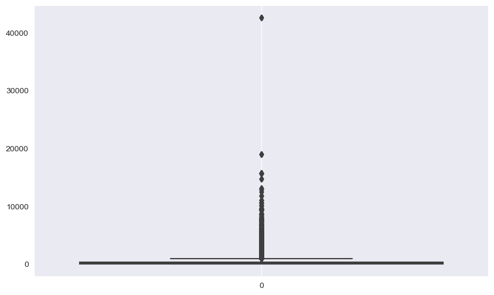

```python
# Checking for outliers in votes
plt.figure(figsize=(10,6))
sns.boxplot(df.votes)
plt.grid()
plt.show()
```

- Upon our research votes under 20,000 are considerable
- We see 1 entry spiking above 40,000, suggests it is a false entry and we will correct with 4000

```python
df.votes = np.where(df.votes>40000,4000,df.votes)
```

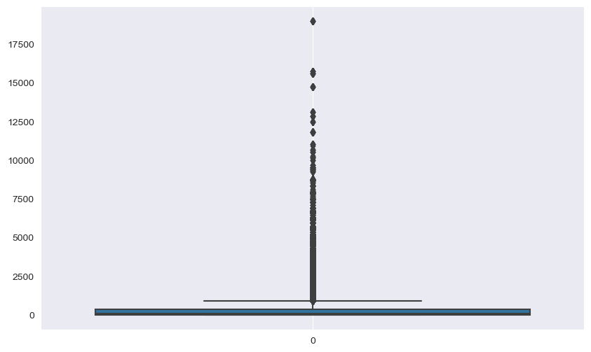

```python
plt.figure(figsize=(10,6))
sns.boxplot(df.votes)
plt.grid()
plt.show()
```

Having examined additional columns, we can confidently conclude that our dataset is devoid of any outliers.

## Exploratory Data Analysis: Visualization, Observations, and Insights

#### Dataset Overview: Recap of Columns for Enhanced Understanding

```python
df.columns
```

```
Index(['name', 'establishment', 'url', 'address', 'city', 'city_id',
       'locality', 'latitude', 'longitude', 'zipcode', 'locality_verbose',
       'cuisines', 'timings', 'average_cost_for_two', 'price_range',
       'highlights', 'aggregate_rating', 'rating_text', 'votes', 'photo_count',
       'delivery', 'takeaway'],
      dtype='object')
```

```python
df.info()
```

```
<class 'pandas.core.frame.DataFrame'>
RangeIndex: 211944 entries, 0 to 211943
Data columns (total 22 columns):
 #   Column                Non-Null Count   Dtype
---  ------                --------------   -----
 0   name                  211944 non-null  object
 1   establishment         211944 non-null  object
 2   url                   211944 non-null  object
 3   address               211944 non-null  object
 4   city                  211944 non-null  object
 5   city_id               211944 non-null  int64
 6   locality              211944 non-null  object
 7   latitude              211944 non-null  float64
 8   longitude             211944 non-null  float64
 9   zipcode               211944 non-null  int64
 10  locality_verbose      211944 non-null  object
 11  cuisines              211944 non-null  object
 12  timings               211944 non-null  object
 13  average_cost_for_two  211944 non-null  int64
 14  price_range           211944 non-null  int64
 15  highlights            211944 non-null  object
 16  aggregate_rating      211944 non-null  float64
 17  rating_text           211944 non-null  object
 18  votes                 211944 non-null  int64
 19  photo_count           211944 non-null  int64
 20  delivery              211944 non-null  int64
 21  takeaway              211944 non-null  int64
dtypes: float64(3), int64(8), object(11)
memory usage: 35.6+ MB
```

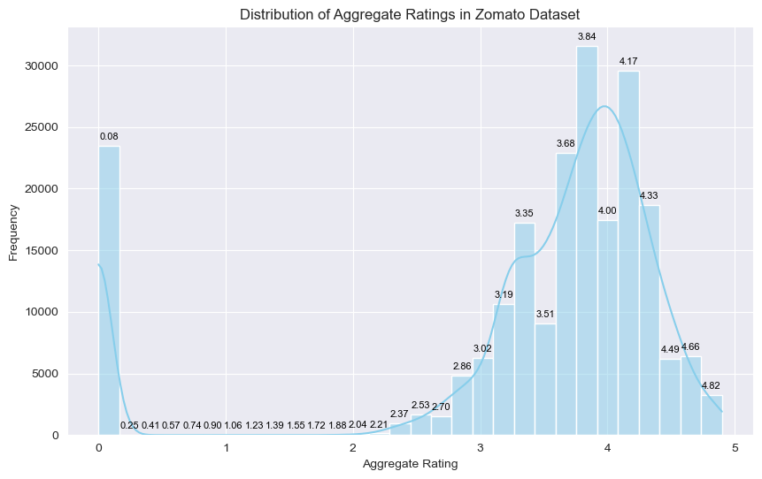

```python
# Distribution of Aggregate Ratings in Zomato Dataset

plt.figure(figsize=(10, 6))
ax = sns.histplot(df['aggregate_rating'], bins=30, kde=True, color='skyblue')

# Annotate values on top of each bar
for p in ax.patches:
    ax.annotate(f'{p.get_x() + p.get_width()/2:.2f}', (p.get_x() + p.get_width() / 2., p.get_height()),
                ha='center', va='baseline', fontsize=8, color='black', xytext=(0, 5),
                textcoords='offset points')

plt.title('Distribution of Aggregate Ratings in Zomato Dataset')
plt.xlabel('Aggregate Rating')
plt.ylabel('Frequency')
plt.grid(True)
plt.show()
```

- A noteworthy observation reveals that a substantial majority of restaurants in the dataset attained a **rating peak at 3.84.**
- The rating trend unfolds with a gradual ascent from 2.37 to 3.19, exhibiting a slight spike at 2.86. Subsequently, a prominent surge is observed at 3.35, followed by a pronounced decline around the 3.5 mark.
- The dataset indicates that the **second-highest rating attained by restaurants is 4.1.** Following this peak, a decline in ratings is notable. **It's observed that achieving a rating of 4.81 is challenging for a substantial number of restaurants.**

The challenge of achieving a **rating of 4.81** suggests that only a select **few restaurants excel in meeting or surpassing these higher expectations, possibly requiring qualitied food, exceptional offerings or service to attain such a rating.**

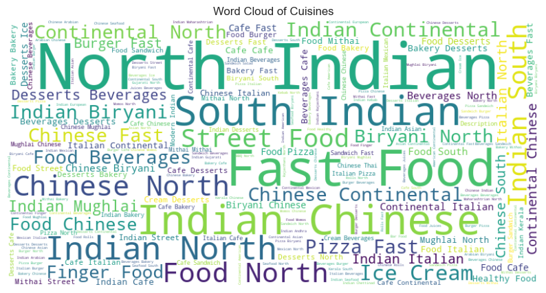

```python
# Generate a string of cuisines from the 'cuisines' column
cuisines_text = ' '.join(df['cuisines'].dropna())

wordcloud = WordCloud(width=800, height=400, background_color='white').generate(cuisines_text)

plt.figure(figsize=(10, 6))
plt.imshow(wordcloud, interpolation='bilinear')
plt.axis('off')
plt.title('Word Cloud of Cuisines')
plt.show()
```

#### Observations and Insights

1. **North Indian Cuisine Dominance:**
   - The word cloud prominently features "North Indian," indicating a significant demand for this cuisine, showcasing **North India as a major market for Zomato.**
2. **Indian Chinese and Tibetan Influence:**
   - The inclusion of "Indian Chinese" suggests a considerable demand, possibly influenced by Tibetan cuisine, particularly popular in North India.
3. **South Indian Appeal Across Regions:**
   - "South Indian" stands out, indicating substantial demand not only in the South but also in the North, **reflecting Zomato's nationwide presence.**
4. **Diverse National Presence:**
   - The word cloud showcases nationwide preferences with mentions of "Indian Biryani," "Pizza," "Burger," "Fast Food," "Mughlai," and "Ice Cream," indicating the diverse and widespread appeal of these cuisines across the country.
5. **Opportunities for Feature Promotion:**
   - The larger representations of certain foods like **Biryani, Pizza, Burger, and Ice Cream** suggest their popularity. Zomato could strategically **promote these items through carousels or featured sections on their platform,** capitalizing on their mass appeal.
6. **Strategic Business Insights:**
   - Zomato can leverage these insights to enhance user experience, tailor marketing strategies, and strategically position popular cuisines to maximize engagement and satisfaction across the diverse culinary landscape of India.

```python
# Understanding influence of Zomato in cities
# In top 10 cities

top10 = df.city.value_counts().head(10)
```

```python
top10
```

```
city
Chennai      11630
Mumbai        6497
Bangalore     4971
Pune          4217
Lucknow       4121
Jabalpur      3994
New Delhi     3918
Jaipur        3713
Kochi         3370
Ajmer         3277
Name: count, dtype: int64
```

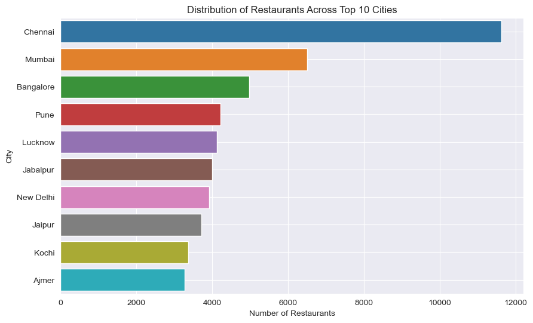

```python
plt.figure(figsize=(10,6))
sns.barplot(x=top10.values,y=top10.index)

plt.title('Distribution of Restaurants Across Top 10 Cities')
plt.xlabel('Number of Restaurants')
plt.ylabel('City')
plt.grid(axis='y')
plt.show()
```

#### Observations and Insights:

1. **Chennai Dominance:**
   - Chennai leads with the highest number of listed restaurants, suggesting a robust market presence.
2. **South Indian Cities in Top Positions:**
   - Mumbai, Bangalore, and Pune, all from the southern region, follow Chennai. This contradicts the initial assumption of a major appeal in the North, emphasizing the widespread popularity of North Indian food in both regions.
3. **Mass Appeal of North Indian Cuisine:**
   - The combined observations from the word cloud and countplot suggest a high demand for North Indian cuisine, potentially attributed to its ease of preparation.
4. **Fast Food Appeal in South India:**
   - The significant presence of fast food establishments in South Indian cities, possibly catering to a younger demographic and migrants, **presents an opportunity for targeted promotions and pricing strategies.**
5. **Lucknow's Biryani Dominance:**
   - Lucknow emerges as a major player in North India, indicating a high demand for Biryani, **potentially a focal point for prominent restaurants in the city.**
6. **New Delhi's Remarkable Presence:**
   - Despite its smaller geographical size, New Delhi holds a noteworthy position, with over 3,800 listed restaurants, underscoring its importance as a key market.

These insights can guide strategic decisions for Zomato, such as tailoring offerings to regional preferences, adjusting pricing strategies, and targeting specific demographics to further enhance business in different cities.

```python
# In least 10 cities

least10 = df.city.value_counts().tail(10)
```

```python
least10
```

```
city
Udupi            234
Neemrana         226
Nasik            209
Secunderabad     183
Gandhinagar      152
Ghaziabad        132
Faridabad        124
Howrah            66
Greater Noida     33
Nayagaon          17
Name: count, dtype: int64
```

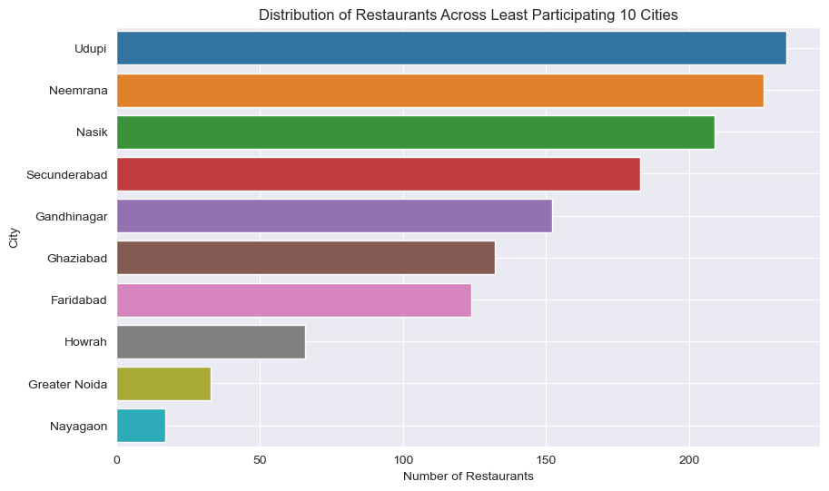

```python
plt.figure(figsize=(10,6))
sns.barplot(x=least10.values,y=least10.index)

plt.title('Distribution of Restaurants Across Least Participating 10 Cities')
plt.xlabel('Number of Restaurants')
plt.ylabel('City')
plt.grid(axis='y')
plt.show()
```

#### Observations and Insights:

1. **Nayagaon's Limited Presence:**
   - Nayagaon, representing the least number of listed restaurants, **can be attributed to its status as a small village near Pune.** Given Pune's already higher restaurant count, the limited presence in Nayagaon may be expected and could be reasonably neglected.
2. **Greater Noida's Opportunity for Growth:**
   - Despite its name suggesting size, Greater Noida surprisingly holds the second-to-last position in terms of listed restaurants. **This presents an opportunity for Zomato to stimulate growth by incentivizing residents with offers and targeting residential areas.**
3. **Challenges in Ghaziabad, Faridabad, and Gandhinagar:**
   - Ghaziabad, Faridabad, and Gandhinagar, despite being notably larger in size, have a relatively low number of listed restaurants. **Zomato could investigate and address potential challenges, encouraging restaurant partnerships, and focusing on marketing strategies targeting residential areas to boost its presence in these locations.**
4. **Udupi, Neemrana, Nasik and Secunderabad:**
   - Cities like Udupi, Neemrana, Nasik, and Secunderabad, with relatively fewer listed restaurants, offer opportunities for Zomato to enhance its presence through tailored strategies, including local collaborations, targeted marketing, and community outreach.

The identified areas for improvement underscore the significance of understanding local dynamics and tailoring strategies to specific geographical nuances. Implementing targeted marketing, promotional offers, and strategic collaborations can be instrumental in enhancing Zomato's presence and engagement in these regions.

```python
# Delivery and Takeaway analyis

df.delivery.value_counts()
```

```
delivery
-1    132573
 1     78335
 0      1036
Name: count, dtype: int64
```

- -1: Indicates a condition or status where delivery is not available or not applicable.
- 1: Represents a condition or status where delivery is available.
- 0: May represent a neutral or undefined condition, potentially used for cases where delivery information is not specified or not applicable.

```python
df.takeaway.value_counts()
```

```
takeaway
-1    211944
Name: count, dtype: int64
```

- This suggests every resturaunt offers takeaway service

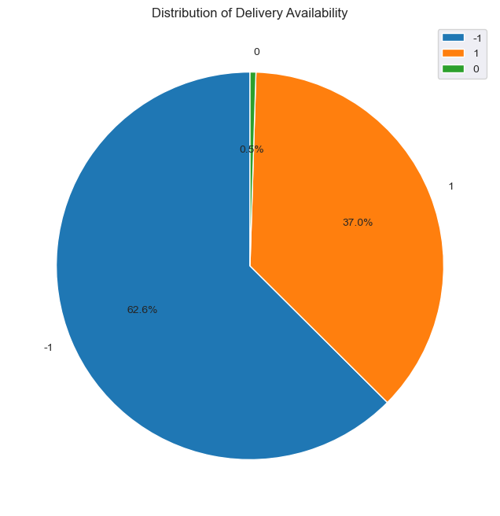

```python
plt.figure(figsize=(8, 8))
plt.pie(df.delivery.value_counts(), labels = df.delivery.value_counts().index, startangle=90,autopct='%1.1f%%')
plt.title('Distribution of Delivery Availability')
plt.legend()
plt.show()
```

The pie chart analysis of the 'delivery' column unveils **valuable insights:**

1. **Majority without Delivery (62.6%):**
   - The substantial portion of restaurants (62.6%) not providing delivery services suggests the presence of reputed establishments or cafes. Zomato could strategically enhance its dine-in services by collaborating with these venues. Initiatives like special offers, featured promotions on the platform, and blog features can help promote and spotlight these restaurants.
2. **Restaurants Offering Delivery (37.0%):**
   - Restaurants providing delivery services represent a significant growth opportunity for Zomato. Promoting these establishments on the app, facilitating seamless deliveries, and offering exclusive deals could amplify customer engagement and contribute to the overall expansion of Zomato's delivery services.

Strategically tailoring approaches for both segments—focused marketing for dine-in experiences with non-delivery restaurants and robust promotion of delivery services for restaurants offering deliveries—can contribute to a balanced and successful growth strategy for Zomato.

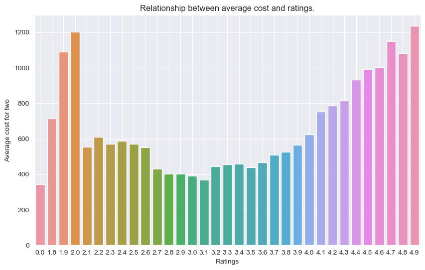

```python
# Relationship between average cost and ratings.

plt.figure(figsize=(10,6))
sns.barplot(x=df.aggregate_rating,y=df.average_cost_for_two, ci=0)

plt.title("Relationship between average cost and ratings.")
plt.xlabel("Ratings")
plt.ylabel("Average cost for two")
plt.grid(True)
plt.show()
```

- **Competitive Focus at 1200 Average Cost:**
  - Regardless of the rating (2 stars or 4.9), significant competition is observed around an average cost per two of 1200.
- **Customer Behavior Insight:**
  - The trend suggests that customers with higher expectations tend to choose restaurants with a higher average cost.
- **Impact on Ratings:**
  - Restaurants meeting or exceeding these expectations often receive close to 5-star ratings, while falling short may result in lower ratings (1, 2, or 3 stars).
- **Correlation with Perceived Value:**
  - The observed correlation highlights the connection between customer satisfaction, perceived value, and the pricing tier of higher-end establishments.

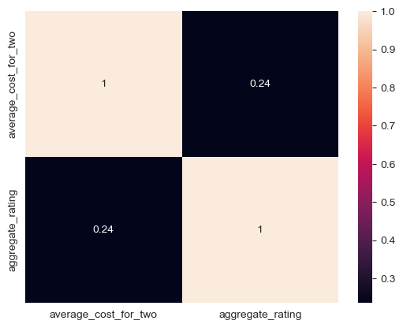

```python
sns.heatmap(df[['average_cost_for_two', 'aggregate_rating']].corr(), annot=True)
```

**Observations and Insights**

Heatmap suggests there is no significant correlation between 'average_cost_for_two' and 'aggregate_rating', which indicates that the two variables are not strongly linearly related. In other words, **the cost of a meal for two people does not have a consistent impact on the aggregate rating of a restaurant.**

This lack of correlation could be due to various factors. It's possible that customers prioritize other aspects such as food quality, service, ambiance, or specific cuisine types over the cost when assigning ratings.

```python
# Checking numbers of resturaunts and hotels listed based upon their price range

df.price_range.value_counts()
```

```
price_range
1    85831
2    77762
3    35767
4    12584
Name: count, dtype: int64
```

- 1: Indicates a relatively lower price range.
- 2: Suggests a moderate price range.
- 3: Represents a higher price range.
- 4: Indicates the highest or premium price range.

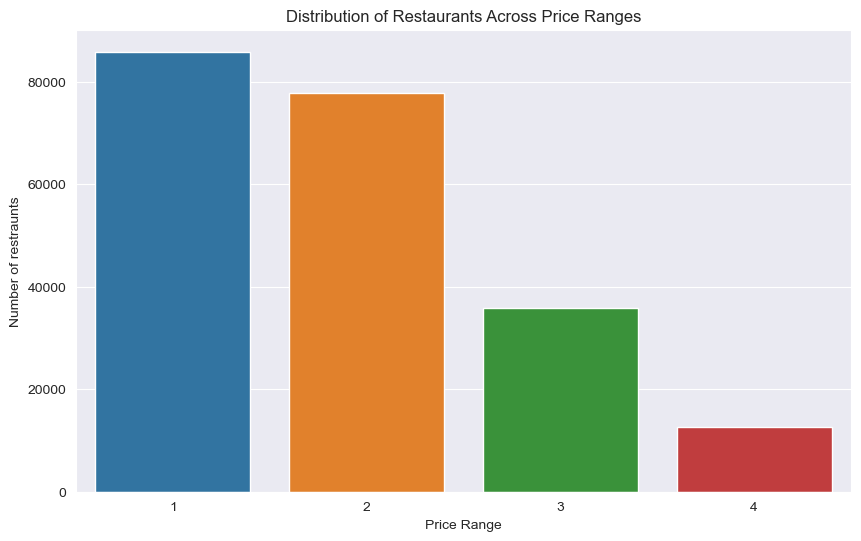

```python
plt.figure(figsize=(10,6))
sns.barplot(x=df.price_range.value_counts().index,y=df.price_range.value_counts().values)

plt.title('Distribution of Restaurants Across Price Ranges')
plt.xlabel('Price Range')
plt.ylabel('Number of restraunts')
plt.show()
```

Interpretation of Price Range Distribution:

The distribution of restaurants across different price ranges on Zomato's platform **reveals a notable concentration in lower and moderate pricing categories**. This observation implies that **Zomato has a significant number of partnerships with small businesses and establishments operating in these price segments.** To foster growth in this sector, **Zomato could strategically focus on this region by offering tailored incentives, reduced marginal charges, and targeted promotional campaigns.** Encouraging and supporting smaller businesses could contribute to the platform's overall success and market expansion.

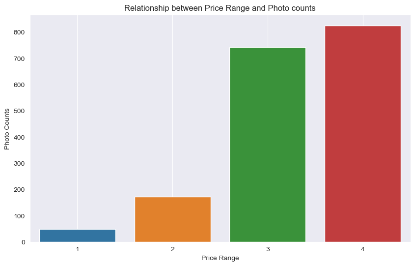

```python
plt.figure(figsize=(10,6))

sns.barplot(x=df.price_range,y=df.photo_count,ci=0)
plt.title("Relationship between Price Range and Photo counts")
plt.ylabel("Photo Counts")
plt.xlabel("Price Range")
plt.grid()
plt.show()
```

**Observation on Relationship Between Price Range and Photo Counts:**

- An analysis of the data reveals a distinctive trend – **restaurants and hotels with higher price ranges tend to provide a greater number of photos compared to their moderately or less priced counterparts.**
- This pattern suggests a potential correlation between pricing tiers and the emphasis on visual representation. Establishments in the higher price range **likely invest more in showcasing their offerings through a richer visual experience.**
- This insight can guide Zomato's understanding of the marketing strategies employed by businesses in different price categories, enabling more targeted and effective promotional approaches.

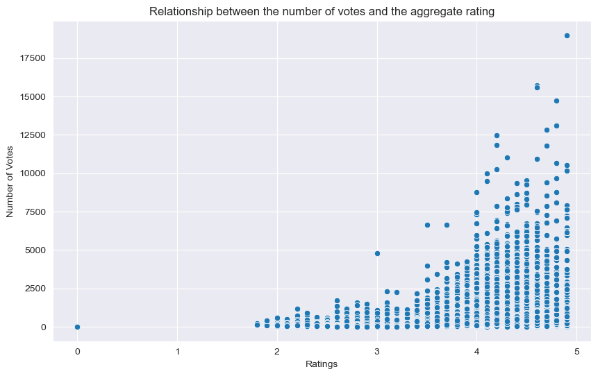

```python
# Relationship between the number of votes and the aggregate rating
plt.figure(figsize=(10,6))
sns.scatterplot(x=df.aggregate_rating,y=df.votes)
plt.title('Relationship between the number of votes and the aggregate rating')
plt.xlabel('Ratings')
plt.ylabel('Number of Votes')
plt.show()
```

#### Observations and Insights:

The graphical analysis of the relationship between the number of votes and the aggregate rating reveals a notable trend – **as the number of votes increases, so does the aggregate rating.** This pattern signifies a positive correlation, indicating that **customers are more likely to provide ratings for restaurants they find satisfactory.** The behavior suggests a tendency to share positive feedback. Understanding this customer feedback behavior, **Zomato can devise incentive programs for restaurants that consistently maintain high ratings. Encouraging positive reviews can not only enhance the brand value of Zomato** but also contribute to a positive and trustworthy user experience for its customers.

## Summary of Project Observations and Insights:

1. **Regional Dynamics:**
   - The distribution of restaurants across cities reflects strong competition in major urban centers, with Chennai leading, followed by Mumbai, Bangalore, and Pune. Surprisingly, strong Zomato presence in South Indian cities contradicts initial assumptions of a Northern market dominance.
2. **Dine-In vs. Delivery:**
   - A significant percentage of restaurants (62.6%) do not provide delivery, potentially indicating reputed or dine-in-focused establishments. Zomato can capitalize on this by enhancing dine-in services through special offers and strategic collaborations.
3. **City-Specific Strategies:**
   - Cities like Greater Noida, Ghaziabad, Faridabad, and Gandhinagar, despite their size, have a lower number of listed restaurants. Targeted marketing and promotion strategies can help Zomato establish a stronger presence in these locations.
4. **Cuisine Preferences:**
   - The word cloud analysis reveals North Indian, Indian Chinese, and South Indian cuisines as popular choices. Zomato can leverage these insights for targeted promotions and partnerships with popular cuisines.
5. **Pricing and Customer Behavior:**
   - Most restaurants fall into lower and moderate price ranges, suggesting a dependence on small businesses. Focusing on incentives, reduced charges, and promotional campaigns for smaller establishments can be beneficial.
6. **Visual Presentation and Pricing:**
   - Establishments in higher price ranges tend to provide more photos, emphasizing the importance of visual representation. Zomato can consider this in marketing strategies to enhance the user experience.
7. **Customer Feedback Behavior:**
   - The positive correlation between the number of votes and aggregate rating indicates customers are more likely to rate positively. Incentive programs for consistently high-rated restaurants can enhance Zomato's brand value.

Incorporating these insights into Zomato's strategic planning can optimize marketing efforts, strengthen regional presence, and improve overall customer satisfaction, contributing to the platform's success and growth.